# Linear Regression Example

In this example, we are playing with a diabetes dataset. Here, ten baseline variables, age, sex, body mass index, average blood pressure, and six blood serum measurements were obtained for each of n = 442 diabetes patients, as well as the response of interest, a quantitative measure of disease progression one year after baseline.

```r
# Load the diabetes dataset
diabetes <- read.csv("diabetes.csv")
head(diabetes)
```

```
##   AGE SEX  BMI  BP  S1    S2 S3 S4     S5 S6   Y
## 1  59   2 32.1 101 157  93.2 38  4 4.8598 87 151
## 2  48   1 21.6  87 183 103.2 70  3 3.8918 69  75
## 3  72   2 30.5  93 156  93.6 41  4 4.6728 85 141
## 4  24   1 25.3  84 198 131.4 40  5 4.8903 89 206
## 5  50   1 23.0 101 192 125.4 52  4 4.2905 80 135
## 6  23   1 22.6  89 139  64.8 61  2 4.1897 68  97
```

### Data Preprocessing

Let’s standardize all columns that are roughly normal or uniformly distributed.

```r
library(caret)
preprocessParams1 <- preProcess(diabetes[c("AGE", "BMI", "BP", "S1", "S2", "S3", "S5", "S6", "Y")], method=c("center", "scale"))
diabetes_trans <- data.frame(predict(preprocessParams1, diabetes))
head(diabetes_trans)
```

```
##           AGE SEX        BMI         BP          S1         S2         S3
## 1  0.79959404   2  1.2956203  0.4593201 -0.92869347 -0.7312360 -0.9114178
## 2 -0.03952235   1 -1.0809553 -0.5528781 -0.17742321 -0.4024301  1.5626428
## 3  1.79127703   2  0.9334755 -0.1190789 -0.95758848 -0.7180838 -0.6794746
## 4 -1.87032173   1 -0.2434953 -0.7697777  0.25600194  0.5248025 -0.7567890
## 5  0.11304427   1 -0.7640785  0.4593201  0.08263188  0.3275189  0.1709838
## 6 -1.94660503   1 -0.8546148 -0.4082784 -1.44880365 -1.6650447  0.8668133
##   S4         S5         S6           Y
## 1  4  0.4180572 -0.3705686 -0.01470281
## 2  3 -1.4349625 -1.9362850 -1.00052508
## 3  4  0.0600875 -0.5445371 -0.14441627
## 4  5  0.4764426 -0.1966001  0.69872119
## 5  4 -0.6717404 -0.9794583 -0.22224434
## 6  2 -0.8646995 -2.0232693 -0.71515547
```

Then apply boxcox transformations for those columns that are skewed.

```r
preprocessParams2 <- preProcess(diabetes_trans[c("S4")], method=c("BoxCox"))
diabetes_trans <- data.frame(predict(preprocessParams2, diabetes_trans))
head(diabetes_trans)
```

```
##           AGE SEX        BMI         BP          S1         S2         S3
## 1  0.79959404   2  1.2956203  0.4593201 -0.92869347 -0.7312360 -0.9114178
## 2 -0.03952235   1 -1.0809553 -0.5528781 -0.17742321 -0.4024301  1.5626428
## 3  1.79127703   2  0.9334755 -0.1190789 -0.95758848 -0.7180838 -0.6794746
## 4 -1.87032173   1 -0.2434953 -0.7697777  0.25600194  0.5248025 -0.7567890
## 5  0.11304427   1 -0.7640785  0.4593201  0.08263188  0.3275189  0.1709838
## 6 -1.94660503   1 -0.8546148 -0.4082784 -1.44880365 -1.6650447  0.8668133
##          S4         S5         S6           Y
## 1 1.3862944  0.4180572 -0.3705686 -0.01470281
## 2 1.0986123 -1.4349625 -1.9362850 -1.00052508
## 3 1.3862944  0.0600875 -0.5445371 -0.14441627
## 4 1.6094379  0.4764426 -0.1966001  0.69872119
## 5 1.3862944 -0.6717404 -0.9794583 -0.22224434
## 6 0.6931472 -0.8646995 -2.0232693 -0.71515547
```

And transform `SEX` to dummy variables.

```r
diabetes_trans["SEX"] <- as.numeric(diabetes_trans$SEX == 1)
head(diabetes_trans)
```

```
##           AGE SEX        BMI         BP          S1         S2         S3
## 1  0.79959404   0  1.2956203  0.4593201 -0.92869347 -0.7312360 -0.9114178
## 2 -0.03952235   1 -1.0809553 -0.5528781 -0.17742321 -0.4024301  1.5626428
## 3  1.79127703   0  0.9334755 -0.1190789 -0.95758848 -0.7180838 -0.6794746
## 4 -1.87032173   1 -0.2434953 -0.7697777  0.25600194  0.5248025 -0.7567890
## 5  0.11304427   1 -0.7640785  0.4593201  0.08263188  0.3275189  0.1709838
## 6 -1.94660503   1 -0.8546148 -0.4082784 -1.44880365 -1.6650447  0.8668133
##          S4         S5         S6           Y
## 1 1.3862944  0.4180572 -0.3705686 -0.01470281
## 2 1.0986123 -1.4349625 -1.9362850 -1.00052508
## 3 1.3862944  0.0600875 -0.5445371 -0.14441627
## 4 1.6094379  0.4764426 -0.1966001  0.69872119
## 5 1.3862944 -0.6717404 -0.9794583 -0.22224434
## 6 0.6931472 -0.8646995 -2.0232693 -0.71515547
```

### Splitting dataset for cross validation

First, we split the data into two groups: a training set and a test set. To do this, the `sample` function is used.

```r
#Preparing Data Sets
trows <- floor(0.65 * nrow(diabetes_trans))
train_idx <- sample(seq_len(nrow(diabetes_trans)), size = trows)

train <- diabetes_trans[train_idx,]
test <- diabetes_trans[-train_idx,]
```

### Data Modeling

Here we create a linear regression model between `Y`, which is our target using all features in the data.

```r
hlm <- lm(formula = Y ~ . , data = train)
summary(hlm)
```

```
##
## Call:
## lm(formula = Y ~ ., data = train)
##
## Residuals:
##      Min       1Q   Median       3Q      Max
## -1.77704 -0.47808 -0.01939  0.45926  2.01782
##
## Coefficients:
##              Estimate Std. Error t value Pr(>|t|)
## (Intercept) -0.395583   0.652861  -0.606 0.545065
## AGE          0.007561   0.046208   0.164 0.870147
## SEX          0.298639   0.096305   3.101 0.002129 **
## BMI          0.290330   0.052971   5.481 9.55e-08 ***
## BP           0.183962   0.051011   3.606 0.000368 ***
## S1          -0.211478   0.330727  -0.639 0.523072
## S2           0.096385   0.269426   0.358 0.720811
## S3          -0.079562   0.176466  -0.451 0.652441
## S4           0.162422   0.473553   0.343 0.731870
## S5           0.401170   0.131355   3.054 0.002478 **
## S6           0.036373   0.049899   0.729 0.466662
## ---
## Signif. codes:  0 '***' 0.001 '**' 0.01 '*' 0.05 '.' 0.1 ' ' 1
##
## Residual standard error: 0.7049 on 276 degrees of freedom
## Multiple R-squared:  0.5206, Adjusted R-squared:  0.5032
## F-statistic: 29.97 on 10 and 276 DF,  p-value: < 2.2e-16
```

Let’s examine the factors that are useful for predicting diabetes progression.

```r
print(hlm$coefficients)
```

```
##  (Intercept)          AGE          SEX          BMI           BP
## -0.395582692  0.007560811  0.298638698  0.290330184  0.183962175
##           S1           S2           S3           S4           S5
## -0.211477542  0.096384570 -0.079562464  0.162422034  0.401170055
##           S6
##  0.036372671
```

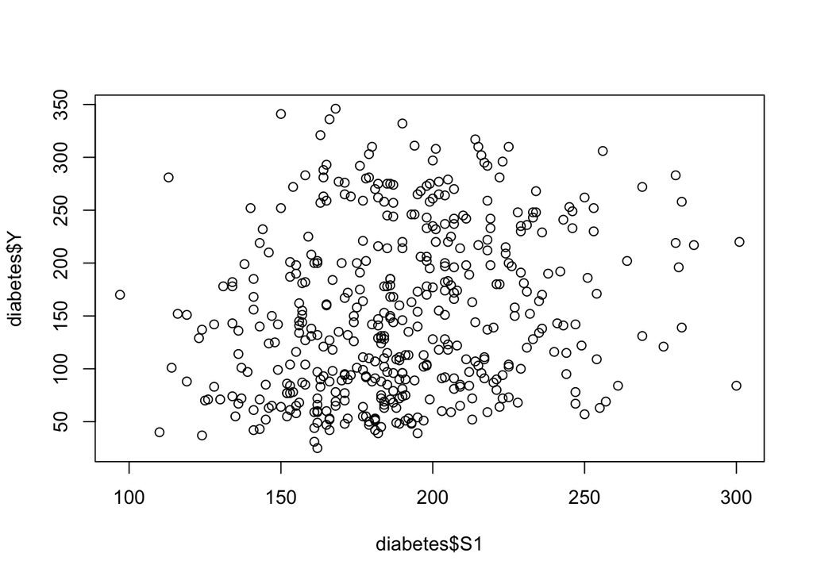

```r
plot(diabetes$S1, diabetes$Y)
```

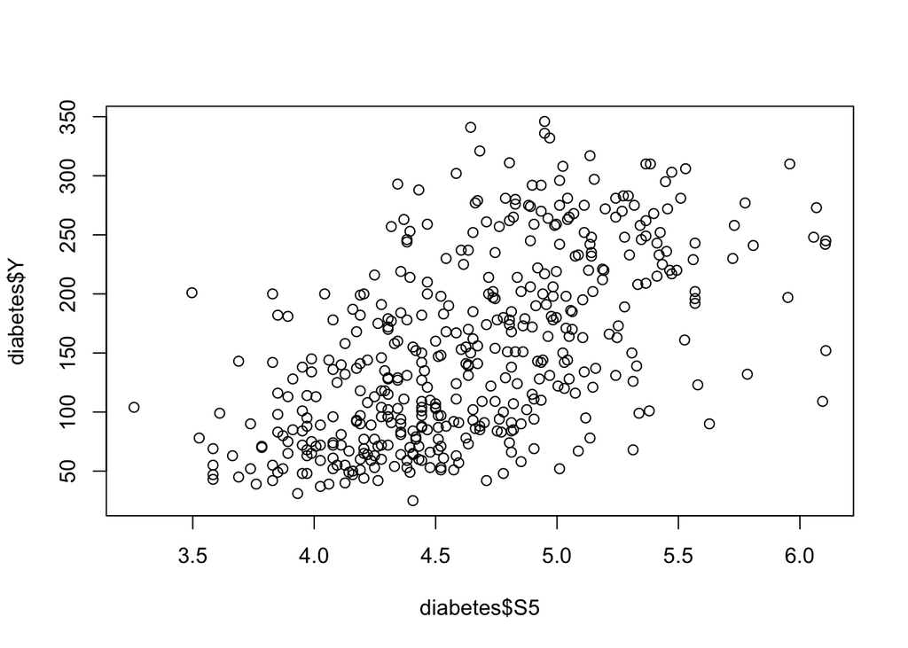

```r
plot(diabetes$S5, diabetes$Y)
```

### Cross validate the model on a test set

```r
yhat = predict(hlm, newdata=test)
R2 <- 1 - (sum((test$Y-yhat)^2)/sum((test$Y-mean(yhat))^2))
R2
```

```
## [1] 0.4962384
```

### Training regression model using Caret

In Caret package, we can use `trainControl` function to automate a lot of training process. `trainControl` function can be used in conjunction with many training algorithms.

In `trainControl` function, you can specify how you are going to perform cross validation (how many folds, repeats). You can specify what methods to use for parameter search or parameter selection or performance analysis. Check out the reference link below for complete set of options.

Here we use trainControl to simply performance 3-fold cross validation on our diabetes data.

`trainControl` function is used in conjunction with `train` function. `train` function can receives a formula and a dataframe, or simply x and y variable. Then you can specify method (in this case, a linear model) and `trainControl` output.

```r
control <- trainControl(method="cv", number=3)
model <- train(Y~., data=diabetes_trans, method="lm", trControl=control)
model
```

```
## Linear Regression
##
## 442 samples
##  10 predictor
##
## No pre-processing
## Resampling: Cross-Validated (3 fold)
## Summary of sample sizes: 295, 294, 295
## Resampling results:
##
##   RMSE       Rsquared
##   0.7119659  0.4988781
##
## Tuning parameter 'intercept' was held constant at a value of TRUE
```

Reference: https://www.rdocumentation.org/packages/caret/versions/6.0-76/topics/trainControl https://www.rdocumentation.org/packages/caret/versions/6.0-76/topics/train